# Exploratory Data Analysis

Choonghyun Ryu

2020-10-14

## Preface

After you have acquired the data, you should do the following:

- Diagnose data quality.
  - If there is a problem with data quality,
  - The data must be corrected or re-acquired.
- **Explore data to understand the data and find scenarios for performing the analysis.**
- Derive new variables or perform variable transformations.

The dlookr package makes these steps fast and easy:

- Performs an data diagnosis or automatically generates a data diagnosis report.
- **Discover data in a variety of ways, and automatically generate EDA(exploratory data analysis) report.**
- Imputate missing values and outliers, resolve skewed data, and binarize continuous variables into categorical variables. And generates an automated report to support it.

This document introduces **EDA(Exploratory Data Analysis)** methods provided by the dlookr package. You will learn how to EDA of `tbl_df` data that inherits from data.frame and `data.frame` with functions provided by dlookr.

dlookr synergy with `dplyr` increases. Particularly in data exploration and data wrangle, it increases the efficiency of the `tidyverse` package group.

## Supported data structures

Data diagnosis supports the following data structures.

- data frame : data.frame class.
- data table : tbl_df class.
- **table of DBMS** : table of the DBMS through tbl_dbi.
  - **Using dplyr backend for any DBI-compatible database.**

## datasets

To illustrate the basic use of EDA in the dlookr package, I use a `Carseats` datasets. `Carseats` in the `ISLR` package is simulation dataset that sells children’s car seats at 400 stores. This data is a data.frame created for the purpose of predicting sales volume.

```r
library(ISLR)
str(Carseats)
'data.frame':   400 obs. of  11 variables:
 $ Sales      : num  9.5 11.22 10.06 7.4 4.15 ...
 $ CompPrice  : num  138 111 113 117 141 124 115 136 132 132 ...
 $ Income     : num  73 48 35 100 64 113 105 81 110 113 ...
 $ Advertising: num  11 16 10 4 3 13 0 15 0 0 ...
 $ Population : num  276 260 269 466 340 501 45 425 108 131 ...
 $ Price      : num  120 83 80 97 128 72 108 120 124 124 ...
 $ ShelveLoc  : Factor w/ 3 levels "Bad","Good","Medium": 1 2 3 3 1 1 3 2 3 3 ...
 $ Age        : num  42 65 59 55 38 78 71 67 76 76 ...
 $ Education  : num  17 10 12 14 13 16 15 10 10 17 ...
 $ Urban      : Factor w/ 2 levels "No","Yes": 2 2 2 2 2 1 2 2 1 1 ...
 $ US         : Factor w/ 2 levels "No","Yes": 2 2 2 2 1 2 1 2 1 2 ...
```

The contents of individual variables are as follows. (Refer to ISLR::Carseats Man page)

- Sales
  - Unit sales (in thousands) at each location
- CompPrice
  - Price charged by competitor at each location
- Income
  - Community income level (in thousands of dollars)
- Advertising
  - Local advertising budget for company at each location (in thousands of dollars)
- Population
  - Population size in region (in thousands)
- Price
  - Price company charges for car seats at each site
- ShelveLoc
  - A factor with levels Bad, Good and Medium indicating the quality of the shelving location for the car seats at each site
- Age
  - Average age of the local population
- Education
  - Education level at each location
- Urban
  - A factor with levels No and Yes to indicate whether the store is in an urban or rural location
- US
  - A factor with levels No and Yes to indicate whether the store is in the US or not

When data analysis is performed, data containing missing values is often encountered. However, Carseats is complete data without missing. Therefore, the missing values are generated as follows. And I created a data.frame object named carseats.

```r
carseats <- ISLR::Carseats

suppressWarnings(RNGversion("3.5.0"))
set.seed(123)
carseats[sample(seq(NROW(carseats)), 20), "Income"] <- NA

suppressWarnings(RNGversion("3.5.0"))
set.seed(456)
carseats[sample(seq(NROW(carseats)), 10), "Urban"] <- NA
```

## Exploratory Data Analysis

dlookr can help to understand the distribution of data by calculating descriptive statistics of numerical data. In addition, correlation between variables is identified and normality test is performed. It also identifies the relationship between target variables and independent variables.:

The following is a list of the EDA functions included in the dlookr package.:

- `describe()` provides descriptive statistics for numerical data.
- `normality()` and `plot_normality()` perform normalization and visualization of numerical data.
- `correlate()` and `plot_correlate()` calculate the correlation coefficient between two numerical data and provide visualization.
- `target_by()` defines the target variable and `relate()` describes the relationship with the variables of interest corresponding to the target variable.
- `plot.relate()` visualizes the relationship to the variable of interest corresponding to the destination variable.
- `eda_report()` performs an exploratory data analysis and reports the results.

## Univariate data EDA

### Calculating descriptive statistics using `describe()`

`describe()` computes descriptive statistics for numerical data. The descriptive statistics help determine the distribution of numerical variables. Like function of dplyr, the first argument is the tibble (or data frame). The second and subsequent arguments refer to variables within that data frame.

The variables of the `tbl_df` object returned by `describe()` are as follows.

- `n` : number of observations excluding missing values
- `na` : number of missing values
- `mean` : arithmetic average
- `sd` : standard devation
- `se_mean` : standrd error mean. sd/sqrt(n)
- `IQR` : interquartile range (Q3-Q1)
- `skewness` : skewness
- `kurtosis` : kurtosis
- `p25` : Q1. 25% percentile
- `p50` : median. 50% percentile
- `p75` : Q3. 75% percentile
- `p01`, `p05`, `p10`, `p20`, `p30` : 1%, 5%, 20%, 30% percentiles
- `p40`, `p60`, `p70`, `p80` : 40%, 60%, 70%, 80% percentiles
- `p90`, `p95`, `p99`, `p100` : 90%, 95%, 99%, 100% percentiles

For example, we can computes the statistics of all numerical variables in `carseats`:

```r
describe(carseats)
Warning: The `x` argument of `as_tibble.matrix()` must have unique column names if `.name_repair` is omitted as of tibble 2.0.0.
Using compatibility `.name_repair`.
This warning is displayed once every 8 hours.
Call `lifecycle::last_warnings()` to see where this warning was generated.
Warning: `cols` is now required when using unnest().
Please use `cols = c(statistic)`
# A tibble: 8 x 26
  variable     n    na   mean    sd se_mean   IQR skewness kurtosis   p00    p01
  <chr>    <int> <int>  <dbl> <dbl>   <dbl> <dbl>    <dbl>    <dbl> <dbl>  <dbl>
1 Sales      400     0   7.50  2.82   0.141  3.93   0.186   -0.0809     0  0.906
2 CompPri~   400     0 125.   15.3    0.767 20     -0.0428   0.0417    77 89.0
3 Income     380    20  68.9  28.1    1.44  48.2    0.0449  -1.09      21 21.8
4 Adverti~   400     0   6.64  6.65   0.333 12      0.640   -0.545      0  0
# ... with 4 more rows, and 15 more variables: p05 <dbl>, p10 <dbl>, p20 <dbl>,
#   p25 <dbl>, p30 <dbl>, p40 <dbl>, p50 <dbl>, p60 <dbl>, p70 <dbl>,
#   p75 <dbl>, p80 <dbl>, p90 <dbl>, p95 <dbl>, p99 <dbl>, p100 <dbl>
```

The following explains the descriptive statistics only for a few selected variables.:

```r
# Select columns by name
describe(carseats, Sales, CompPrice, Income)
Warning: `cols` is now required when using unnest().
Please use `cols = c(statistic)`
# A tibble: 3 x 26
  variable     n    na   mean    sd se_mean   IQR skewness kurtosis   p00    p01
  <chr>    <int> <int>  <dbl> <dbl>   <dbl> <dbl>    <dbl>    <dbl> <dbl>  <dbl>
1 Sales      400     0   7.50  2.82   0.141  3.93   0.186   -0.0809     0  0.906
2 CompPri~   400     0 125.   15.3    0.767 20     -0.0428   0.0417    77 89.0
3 Income     380    20  68.9  28.1    1.44  48.2    0.0449  -1.09      21 21.8
# ... with 15 more variables: p05 <dbl>, p10 <dbl>, p20 <dbl>, p25 <dbl>,
#   p30 <dbl>, p40 <dbl>, p50 <dbl>, p60 <dbl>, p70 <dbl>, p75 <dbl>,
#   p80 <dbl>, p90 <dbl>, p95 <dbl>, p99 <dbl>, p100 <dbl>
# Select all columns between year and day (inclusive)
describe(carseats, Sales:Income)
Warning: `cols` is now required when using unnest().
Please use `cols = c(statistic)`
# A tibble: 3 x 26
  variable     n    na   mean    sd se_mean   IQR skewness kurtosis   p00    p01
  <chr>    <int> <int>  <dbl> <dbl>   <dbl> <dbl>    <dbl>    <dbl> <dbl>  <dbl>
1 Sales      400     0   7.50  2.82   0.141  3.93   0.186   -0.0809     0  0.906
2 CompPri~   400     0 125.   15.3    0.767 20     -0.0428   0.0417    77 89.0
3 Income     380    20  68.9  28.1    1.44  48.2    0.0449  -1.09      21 21.8
# ... with 15 more variables: p05 <dbl>, p10 <dbl>, p20 <dbl>, p25 <dbl>,
#   p30 <dbl>, p40 <dbl>, p50 <dbl>, p60 <dbl>, p70 <dbl>, p75 <dbl>,
#   p80 <dbl>, p90 <dbl>, p95 <dbl>, p99 <dbl>, p100 <dbl>
# Select all columns except those from year to day (inclusive)
describe(carseats, -(Sales:Income))
Warning: `cols` is now required when using unnest().
Please use `cols = c(statistic)`
# A tibble: 5 x 26
  variable     n    na   mean     sd se_mean   IQR skewness kurtosis   p00   p01
  <chr>    <int> <int>  <dbl>  <dbl>   <dbl> <dbl>    <dbl>    <dbl> <dbl> <dbl>
1 Adverti~   400     0   6.64   6.65   0.333  12     0.640    -0.545     0   0
2 Populat~   400     0 265.   147.     7.37  260.   -0.0512   -1.20     10  16.0
3 Price      400     0 116.    23.7    1.18   31    -0.125     0.452    24  55.0
4 Age        400     0  53.3   16.2    0.810  26.2  -0.0772   -1.13     25  25
# ... with 1 more row, and 15 more variables: p05 <dbl>, p10 <dbl>, p20 <dbl>,
#   p25 <dbl>, p30 <dbl>, p40 <dbl>, p50 <dbl>, p60 <dbl>, p70 <dbl>,
#   p75 <dbl>, p80 <dbl>, p90 <dbl>, p95 <dbl>, p99 <dbl>, p100 <dbl>
```

By using dplyr, You can sort by `left or right skewed size`(skewness).:

```r
carseats %>%
  describe() %>%
  select(variable, skewness, mean, p25, p50, p75) %>%
  filter(!is.na(skewness)) %>%
  arrange(desc(abs(skewness)))
Warning: `cols` is now required when using unnest().
Please use `cols = c(statistic)`
# A tibble: 8 x 6
  variable    skewness   mean    p25    p50    p75
  <chr>          <dbl>  <dbl>  <dbl>  <dbl>  <dbl>
1 Advertising   0.640    6.64   0      5     12
2 Sales         0.186    7.50   5.39   7.49   9.32
3 Price        -0.125  116.   100    117    131
4 Age          -0.0772  53.3   39.8   54.5   66
# ... with 4 more rows
```

The `describe()` function supports the `group_by()` function syntax of `dplyr`.

```r
carseats %>%
  group_by(US) %>%
  describe(Sales, Income)
Warning: `cols` is now required when using unnest().
Please use `cols = c(statistic)`
# A tibble: 4 x 27
  variable US        n    na  mean    sd se_mean   IQR skewness kurtosis   p00
  <chr>    <fct> <dbl> <dbl> <dbl> <dbl>   <dbl> <dbl>    <dbl>    <dbl> <dbl>
1 Sales    No      142     0  6.82  2.60   0.218  3.44   0.323     0.808  0
2 Sales    Yes     258     0  7.87  2.88   0.179  4.23   0.0760   -0.326  0.37
3 Income   No      130    12 65.8  28.2    2.48  50      0.100    -1.14  22
4 Income   Yes     250     8 70.4  27.9    1.77  48      0.0199   -1.06  21
# ... with 16 more variables: p01 <dbl>, p05 <dbl>, p10 <dbl>, p20 <dbl>,
#   p25 <dbl>, p30 <dbl>, p40 <dbl>, p50 <dbl>, p60 <dbl>, p70 <dbl>,
#   p75 <dbl>, p80 <dbl>, p90 <dbl>, p95 <dbl>, p99 <dbl>, p100 <dbl>
```

```r
carseats %>%
  group_by(US, Urban) %>%
  describe(Sales, Income)
Warning: `cols` is now required when using unnest().
Please use `cols = c(statistic)`
# A tibble: 12 x 28
  variable US    Urban     n    na  mean    sd se_mean   IQR skewness kurtosis
  <chr>    <fct> <fct> <dbl> <dbl> <dbl> <dbl>   <dbl> <dbl>    <dbl>    <dbl>
1 Sales    No    No       46     0  6.46  2.72   0.402 3.15    0.0889    1.53
2 Sales    No    Yes      92     0  7.00  2.58   0.269 3.49    0.492     0.306
3 Sales    No    <NA>      4     0  6.99  1.28   0.639 0.827   1.69      3.16
4 Sales    Yes   No       69     0  8.23  2.65   0.319 4.1    -0.0212   -0.777
# ... with 8 more rows, and 17 more variables: p00 <dbl>, p01 <dbl>, p05 <dbl>,
#   p10 <dbl>, p20 <dbl>, p25 <dbl>, p30 <dbl>, p40 <dbl>, p50 <dbl>,
#   p60 <dbl>, p70 <dbl>, p75 <dbl>, p80 <dbl>, p90 <dbl>, p95 <dbl>,
#   p99 <dbl>, p100 <dbl>
```

### Test of normality on numeric variables using `normality()`

`normality()` performs a normality test on numerical data. `Shapiro-Wilk normality test` is performed. If the number of observations is larger than 5000, 5000 observations are extracted by random simple sampling and then tested.

The variables of `tbl_df` object returned by `normality()` are as follows.

- `statistic` : Statistics of the Shapiro-Wilk test
- `p_value` : p-value of the Shapiro-Wilk test
- `sample` : Number of sample observations performed Shapiro-Wilk test

`normality()` performs the normality test for all numerical variables of `carseats` as follows.:

```r
normality(carseats)
Warning: `cols` is now required when using unnest().
Please use `cols = c(statistic)`
# A tibble: 8 x 4
  vars        statistic  p_value sample
  <chr>           <dbl>    <dbl>  <dbl>
1 Sales           0.995 2.54e- 1    400
2 CompPrice       0.998 9.77e- 1    400
3 Income          0.961 1.52e- 8    400
4 Advertising     0.874 1.49e-17    400
# ... with 4 more rows
```

The following example performs a normality test on only a few selected variables.

```r
# Select columns by name
normality(carseats, Sales, CompPrice, Income)
Warning: `cols` is now required when using unnest().
Please use `cols = c(statistic)`
# A tibble: 3 x 4
  vars      statistic      p_value sample
  <chr>         <dbl>        <dbl>  <dbl>
1 Sales         0.995 0.254           400
2 CompPrice     0.998 0.977           400
3 Income        0.961 0.0000000152    400

# Select all columns between year and day (inclusive)
normality(carseats, Sales:Income)
Warning: `cols` is now required when using unnest().
Please use `cols = c(statistic)`
# A tibble: 3 x 4
  vars      statistic      p_value sample
  <chr>         <dbl>        <dbl>  <dbl>
1 Sales         0.995 0.254           400
2 CompPrice     0.998 0.977           400
3 Income        0.961 0.0000000152    400

# Select all columns except those from year to day (inclusive)
normality(carseats, -(Sales:Income))
Warning: `cols` is now required when using unnest().
Please use `cols = c(statistic)`
# A tibble: 5 x 4
  vars        statistic  p_value sample
  <chr>           <dbl>    <dbl>  <dbl>
1 Advertising     0.874 1.49e-17    400
2 Population      0.952 4.08e-10    400
3 Price           0.996 3.90e- 1    400
4 Age             0.957 1.86e- 9    400
# ... with 1 more row
```

You can use dplyr to sort non-normal distribution variables by p_value.:

```r
library(dplyr)

carseats %>%
  normality() %>%
  filter(p_value <= 0.01) %>%
  arrange(abs(p_value))
Warning: `cols` is now required when using unnest().
Please use `cols = c(statistic)`
# A tibble: 5 x 4
  vars        statistic  p_value sample
  <chr>           <dbl>    <dbl>  <dbl>
1 Advertising     0.874 1.49e-17    400
2 Education       0.924 2.43e-13    400
3 Population      0.952 4.08e-10    400
4 Age             0.957 1.86e- 9    400
# ... with 1 more row
```

In particular, the `Advertising` variable is considered to be the most out of the normal distribution.

The `normality()` function supports the `group_by()` function syntax in the `dplyr` package.

```r
carseats %>%
  group_by(ShelveLoc, US) %>%
  normality(Income) %>%
  arrange(desc(p_value))
Warning: `cols` is now required when using unnest().
Please use `cols = c(statistic)`
# A tibble: 6 x 6
  variable ShelveLoc US    statistic p_value sample
  <chr>    <fct>     <fct>     <dbl>   <dbl>  <dbl>
1 Income   Bad       No        0.969  0.470      34
2 Income   Bad       Yes       0.958  0.0343     62
3 Income   Good      No        0.902  0.0328     24
4 Income   Good      Yes       0.955  0.0296     61
# ... with 2 more rows
```

The `Income` variable does not follow the normal distribution. However, if the `US` is `No` and the `ShelveLoc` is `Good` or `Bad` at the significance level of 0.01, it follows the normal distribution.

In the following, we perform `normality test of log(Income)` for each combination of `ShelveLoc` and `US` variables to inquire about normal distribution cases.

```r
carseats %>%
  mutate(log_income = log(Income)) %>%
  group_by(ShelveLoc, US) %>%
  normality(log_income) %>%
  filter(p_value > 0.01)
Warning: `cols` is now required when using unnest().
Please use `cols = c(statistic)`
# A tibble: 1 x 6
  variable   ShelveLoc US    statistic p_value sample
  <chr>      <fct>     <fct>     <dbl>   <dbl>  <dbl>
1 log_income Bad       No        0.940  0.0737     34
```

### Normalization visualization of numerical variables using `plot_normality()`

`plot_normality()` visualizes the normality of numeric data.

The information that `plot_normality()` visualizes is as follows.

- `Histogram of original data`
- `Q-Q plot of original data`
- `histogram of log transformed data`
- `Histogram of square root transformed data`

Numerical data following a `power-law distribution` are often encountered in data analysis. Since the numerical data following the power distribution is transformed into the normal distribution by performing the log and sqrt transform, the histogram of the data for the log and sqrt transform is drawn.

`plot_normality()` can also specify several variables like `normality()` function.

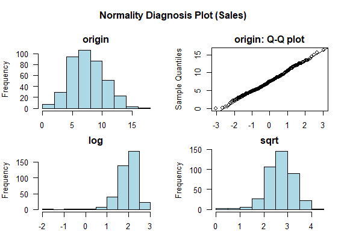

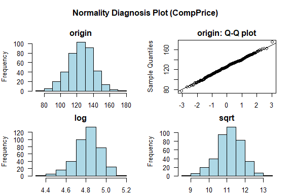

```r
# Select columns by name
plot_normality(carseats, Sales, CompPrice)
```

The `plot_normality()` function also supports the `group_by()` function syntax in the `dplyr` package.

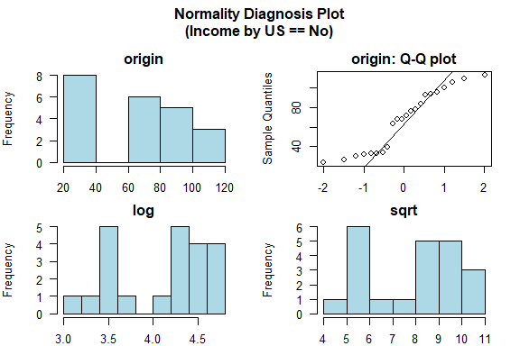

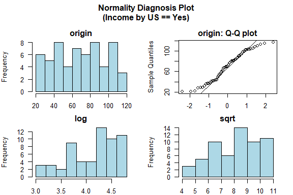

```r
carseats %>%
  filter(ShelveLoc == "Good") %>%
  group_by(US) %>%
  plot_normality(Income)
```

## Bivariate data EDA

### Calculation of `correlation coefficient` using `correlate()`

`Correlate()` finds the correlation coefficient of all combinations of `carseats` numerical variables as follows:

```r
correlate(carseats)
# A tibble: 56 x 3
  var1        var2  coef_corr
  <fct>       <fct>     <dbl>
1 CompPrice   Sales    0.0641
2 Income      Sales    0.151
3 Advertising Sales    0.270
4 Population  Sales    0.0505
# ... with 52 more rows
```

```r
# Select columns by name
correlate(carseats, Sales, CompPrice, Income)
# A tibble: 21 x 3
  var1      var2      coef_corr
  <fct>     <fct>         <dbl>
1 CompPrice Sales        0.0641
2 Income    Sales        0.151
3 Sales     CompPrice    0.0641
4 Income    CompPrice   -0.0761
# ... with 17 more rows

# Select all columns between year and day (inclusive)
correlate(carseats, Sales:Income)
# A tibble: 21 x 3
  var1      var2      coef_corr
  <fct>     <fct>         <dbl>
1 CompPrice Sales        0.0641
2 Income    Sales        0.151
3 Sales     CompPrice    0.0641
4 Income    CompPrice   -0.0761
# ... with 17 more rows

# Select all columns except those from year to day (inclusive)
correlate(carseats, -(Sales:Income))
# A tibble: 35 x 3
  var1        var2  coef_corr
  <fct>       <fct>     <dbl>
1 Advertising Sales    0.270
2 Population  Sales    0.0505
3 Price       Sales   -0.445
4 Age         Sales   -0.232
# ... with 31 more rows
```

`correlate()` produces `two pairs of variable` combinations. So you can use the following `filter()` function to get the correlation coefficient for `a pair of variable` combinations:

```r
carseats %>%
  correlate(Sales:Income) %>%
  filter(as.integer(var1) > as.integer(var2))
# A tibble: 3 x 3
  var1      var2      coef_corr
  <fct>     <fct>         <dbl>
1 CompPrice Sales        0.0641
2 Income    Sales        0.151
3 Income    CompPrice   -0.0761
```

The `correlate()` function also supports the `group_by()` function syntax in the `dplyr` package.

```r
carseats %>%
  filter(ShelveLoc == "Good") %>%
  group_by(Urban, US) %>%
  correlate(Sales) %>%
  filter(abs(coef_corr) > 0.5)
# A tibble: 10 x 5
  Urban US    var1  var2       coef_corr
  <fct> <fct> <fct> <fct>          <dbl>
1 No    No    Sales Population    -0.530
2 No    No    Sales Price         -0.838
3 No    Yes   Sales Price         -0.630
4 Yes   No    Sales Price         -0.833
# ... with 6 more rows
```